# Muestrador de Gibbs

Diego Uriarte

14/9/2018

## ¿Qué es el muestrador de Gibbs?

- Permite muestrar de una distribución sin tener que calcular la densidad.
- Está basada en cadenas de Markov
- Queremos muestrar de f(x)

$$f(x) = \int \cdots \int f(x, y_1, \cdots, y_p) dy_1 \cdots dy_p$$

- ¿Qué podemos hacer?
- Resolver analítica o numéricamente, pero ¿si no se puede?

## ¿Qué es una cadena de Markov?

## ¿Cómo funciona el muestrador de Gibbs? (i)

- Ilustraremos con un ejemplo bivariado. Queremos muestras de $f(x)$ (distribuida de manera conjunta con $y$). Conocemos las condicionales $f(x|y)$ y $f(y|x)$.
- Se especifica un valor inicial para $Y'_0 = y'_0$.
- Se obtiene apartir de las condicionales una sucesión de muestras para x e y:

$$X'_j \sim f(x|Y'_j = y'_j)$$
$$Y'_{j+1} \sim f(y|X'_j = x'_j)$$

## ¿Cómo funciona el muestrador de Gibbs? (ii)

- Obtenemos así una secuencia: $Y'_0, X'_0, Y'_1, X'_1,\cdots Y'_k, X'_k,$
- Resulta que bajo algunas condiciones generales, cuando $k \rightarrow \infty$, $X'_k$ es efectivamente una muestra de $f(x)$

## Aplicación I

- Tenemos X e Y que tienen distribuciones condicionales del tipo exponencial (restringidas al intervalo $(0,B)$:

$$f(x|y) \propto y e^{-yx}, 0 < x < B < \infty \\
f(y|x) \propto x e^{-xy}, 0 < y < B < \infty$$

## Distribución

- Tomamos B = 5, se mantienen 25000 repeticiones y se desechan las primeras 1500.Los muestreos se realizan de distribuciones truncas exponenciales.

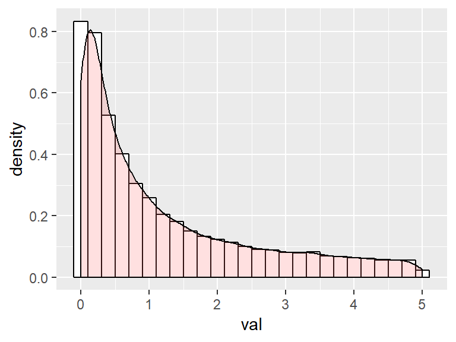

## Una prueba simple de la convergencia del muestrador de Gibbs

Mostraremos como converge el muestreo tomando como ejemplo una distribución bivariada, donde X e Y se distribuyen Bernoulli de manera conjunta.

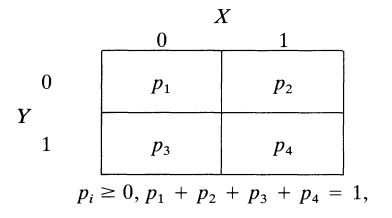

La distribución conjunta de X, Y está dada por:

$$\begin{bmatrix}f_{x,y}(0,0) & f_{x,y}(1,0)\\
f_{x,y}(0,1) & f_{x,y}(1,1)
\end{bmatrix}=\begin{bmatrix}p_{1} & p_{2}\\
p_{\text{3}} & p_{4}
\end{bmatrix}$$

La marginal de X es:

$$f_x = \begin{bmatrix} p_1 + p_3 & p_2 + p_4
\end{bmatrix}$$

Determinamos las probabilidades condicionales $X|Y = y$ e $Y|X = x$, formulando las siguientes matrices:

$$A_{y|x}=\begin{bmatrix} Prob(Y=0|X=0) & Prob(Y=1|X=0)\\
Prob(Y=0|X=1)& Prob(Y=1|X=1)
\end{bmatrix}
=
\begin{bmatrix} \frac{p_1}{p_1+p_3} & \frac{p_3}{p_1+p_3}\\
\frac{p_2}{p_2+p_4}& \frac{p_4}{p_2+p_4}
\end{bmatrix}$$

$$A_{x|y}=\begin{bmatrix} Prob(X=0|Y=0) & Prob(X=1|Y=0)\\
Prob(X=0|Y=1)& Prob(X=1|Y=1)
\end{bmatrix}
=
\begin{bmatrix} \frac{p_1}{p_1+p_2} & \frac{p_2}{p_1+p_2}\\
\frac{p_3}{p_3+p_4}& \frac{p_4}{p_3+p_4}
\end{bmatrix}$$

Dado que estamos interesados en muestrar de la marginal de X, nos interesan los valores $X'_0, X'_1, X'_2, \cdots$. Sin embargo, para ir de $X'_0 \rightarrow X'_1$ debemos muestrar $Y'_1$, es decir, $X'_0 \rightarrow Y'_1 \rightarrow X'_1$.

$$P(X'_1 = x_1 |X'_0 = x_0) = \sum_y P(X'_1 = x_1 |Y'_1 = y) \times P(Y'_1 = y_1 |X'_0 = x_0)$$

Para este caso en particular, se tiene que la matrices de transición para x está dada por:

$$A_{x|x} = A_{y|x} A_{x|y}$$

Ahora, es directo calcular la distribución marginal de realización k, $X'_k$:

$f_k = f_0 A^k_{x|x} = (f_0 A^{k-1}_{x|x})A_{x|x} = f_{k-1}A_{x|x}$

Bajo ciertas condiciones, se tiene un punto fijo tal que:

$$f = f A_{x|x}$$

En nuestro caso simple:

$$\begin{aligned}
f_x A_{x|x} &= f_x A_{y|x} A_{x|y} \\
&= \begin{bmatrix}
p_1 + p_3 & p_2 + p_4
\end{bmatrix}
\begin{bmatrix}
\frac{p_1}{p_1+p_3} & \frac{p_3}{p_1+p_3}\\
\frac{p_2}{p_2+p_4}& \frac{p_4}{p_2+p_4}
\end{bmatrix}
\begin{bmatrix}
\frac{p_1}{p_1+p_2} & \frac{p_2}{p_1+p_2}\\
\frac{p_3}{p_3+p_4}& \frac{p_4}{p_3+p_4}
\end{bmatrix} \\
&= \begin{bmatrix}
p_1 + p_2 & p_3 + p_4
\end{bmatrix}
\begin{bmatrix}
\frac{p_1}{p_1+p_2} & \frac{p_2}{p_1+p_2}\\
\frac{p_3}{p_3+p_4}& \frac{p_4}{p_3+p_4}
\end{bmatrix}\\
&= \begin{bmatrix}
p_1 + p_3 & p_2 + p_4
\end{bmatrix} \\
&= f_x
\end{aligned}$$

## Intuición para el caso bivariado

¿Cómo es que podemos llegar a partir de las condicionales a la marginal?

- Conocemos $f_{X|Y}(x|y)$ y $f_{Y|X}(y|x)$. Si queremos la marginal, por definición:

$$f_X(x) = \int f_{xy}(x,y)dy$$
- Por Bayes sabemos que: $f_{xy}(x,y) = f_{X|Y}(x|y)f_Y(y)$, por tanto:

$$f_X(x) = \int f_{X|Y}(x|y)f_Y(y)dy$$
De manera similar, tenemos $f_{xy}(x,y) = f_{Y|X}(y|x)f_X(y)$ con $f_Y(y) = \int f_{Y|X}(y|x)f_X(x)dx$.

Reemplazando:

$$\begin{aligned}
f_X(x) &= \int f_{X|Y}(x|y)\int f_{Y|X}(y|t)f_X(t)dtdy \\
&= \int \left [ \int f_{X|Y}(x|y) f_{Y|X}(y|t) dy \right ]f_X(t)dt \\
&= \int h(x,t)f_X(t)dt
\end{aligned}$$

con $h(x,t) = \left [ \int f_{X|Y}(x|y) f_{Y|X}(y|t) dy \right ]$.

- Llegamos a lo que se conoce como una ecuación de punto fijo integral.
- La secuencia de Gibbs es una manera de converger a la solución de la ecuación.

**¿Siempre tiene solución?**

Veamos el primer ejemplo, pero sin acotar las distribuciones condicionales.

$$f(x|y) = y e^{-yx}, 0 < x < \infty \\
f(y|x) = x e^{-xy}, 0 < y < \infty$$
$$\begin{aligned}
f_{X}(x) &= \int \left [\int y\exp^{-yx}t\exp^{-ty}dy \right]f_X(t)dt \\
&= \int \left [\frac{t}{(x+t)^2} \right]f_X(t)dt
\end{aligned}$$

Y notamos que $f_X(t) = 1/t$ es solución puesto que:

$$\begin{aligned}
\frac{1}{x} &= \int_0^\infty \left [\frac{t}{(x+t)^2} \right]\frac{1}{t}dt \\
&= \int_0^\infty \left [\frac{1}{(x+t)^2} \right]dt \\
&= \left [\frac{-1}{(x+t)} \right]_{t=0}^{t=\infty} \\
&= 0 - \frac{-1}{x} = \frac{1}{x}\\
\end{aligned}$$

Pero cuando intentamos aplicar el muestrador de Gibbs a estas condicionales, no obtenemos convergencia:

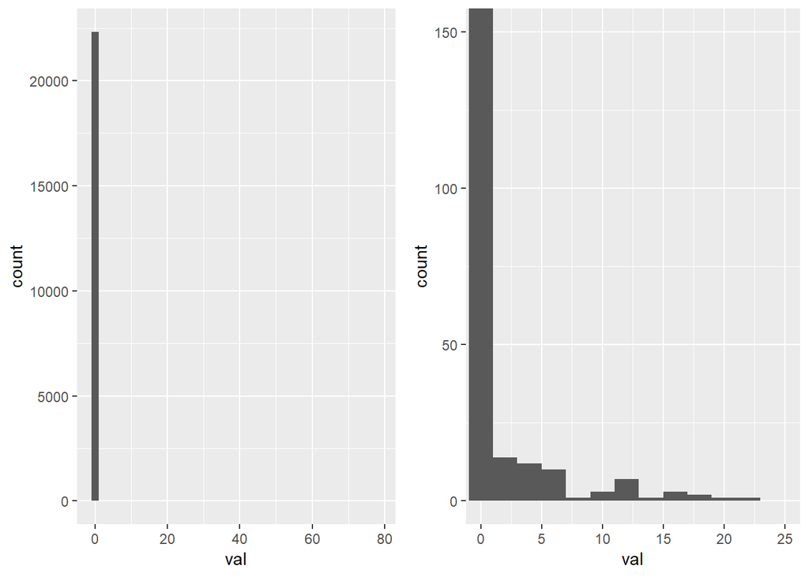

Vemos que ahora el procedimiento de Gibbs no converge puesto que x toma valores cada vez más grandes.

Podemos evitar esto si truncamos las distribuciones condicionales de manera que se cumpla:

$$\int_0^B f_X(x)dx < \infty$$

Vemos que en caso sin truncar, las marginal no integra a un número finito: $\int_0^\infty \frac{1}{x}dx \rightarrow \infty$

Una condición para que algoritmo converga es que la marginal sea una función de densidad $\int f_X(x)dx < \infty$. Una manera de segurar esto es limitando las condicionales.